# Poweranalysis

CK

24/08/2020

# The data set

The data consists of measurements of 36 pasture-soil samples (0－10cm) which are historically contaminated with dieldrin residues. Dieldrin is extremely persistent and therefore still found in the surface soil after three decades of natural attenuation.

The samples were taken in 12 paddocks in two different soils, with three field replicates at representative areas of each paddock. So overall the data consists of:

- 2 soils
  - 12 paddocks (7 + 5)
    - 36 samples (3 per paddock, 21 + 15)  
      **Each sample is a composite of 8-10 soil cores which represents and area of the paddock.**

Total dieldrin loss (%) since 24-30 years was recorded per paddock. Thus, dieldrin residue concentrations (µg/g soil) and other soil measurements were measured for all samples (n = 36) but dieldrin loss (%) was available per paddock only (n = 12).

**Data table (n = 36):**

|  | #SampleID | Soil | Paddock | Farm | D1517 | DDT1517 | TC | CN | HC | P | pH |
| --- | --- | --- | --- | --- | --- | --- | --- | --- | --- | --- | --- |
| 1 | C01 | Kurosol | 1 | A | 0.099 | 0.6520 | 35.50 | 10.86 | 0.3253521 | 38.26 | 4.52 |
| 2 | C02 | Kurosol | 1 | A | 0.220 | 1.6810 | 31.00 | 10.54 | 0.4367742 | 50.98 | 4.44 |
| 3 | C03 | Kurosol | 1 | A | 0.180 | 1.0210 | 34.16 | 10.68 | 0.3395785 | 47.58 | 4.56 |
| 4 | C04 | Kurosol | 2 | A | 0.245 | 1.2200 | 40.20 | 10.58 | 0.3353234 | 56.28 | 4.34 |
| 5 | C05 | Kurosol | 2 | A | 0.255 | 1.5815 | 39.38 | 10.47 | 0.3351955 | 60.19 | 4.37 |
| 22 | C22 | Chromosol | 8 | D | 0.650 | 2.2070 | 61.28 | 15.06 | 0.2880222 | 40.84 | 4.26 |
| 23 | C23 | Chromosol | 8 | D | 0.655 | 2.0860 | 64.86 | 14.58 | 0.2935553 | 39.05 | 4.40 |
| 24 | C24 | Chromosol | 8 | D | 0.715 | 2.0410 | 68.16 | 14.11 | 0.2615904 | 41.66 | 4.36 |
| 25 | C25 | Chromosol | 9 | D | 0.870 | 0.9735 | 73.57 | 12.45 | 0.3090934 | 23.84 | 4.63 |
| 26 | C26 | Chromosol | 9 | D | 0.765 | 0.8640 | 63.88 | 14.62 | 0.2966500 | 6.24 | 4.36 |
| 27 | C27 | Chromosol | 9 | D | 0.880 | 0.9645 | 73.17 | 13.68 | 0.3038130 | 21.13 | 4.58 |

## Dieldrin concentrations

**Dieldrin concentrations (n=36) were approximately log-normal**

```
##
##  Shapiro-Wilk normality test
##
## data:  log10(metadata2$D1517)
## W = 0.94875, p-value = 0.0955
```

**Distribution of dieldrin concentrations (log-scale)**

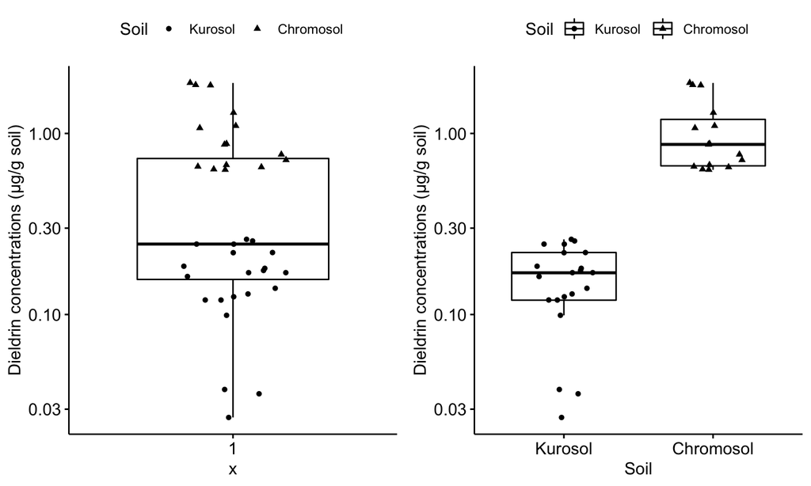

**Dieldrin concentrations per soil and paddock:**

| Soil | Dieldrin | n | mean | sd |
| --- | --- | --- | --- | --- |
| Kurosol | D1517 | 21 | 0.158 | 0.070 |
| Chromosol | D1517 | 15 | 1.036 | 0.473 |

| Paddock | Dieldrin | n | mean | se |
| --- | --- | --- | --- | --- |
| 1 | D1517 | 3 | 0.166 | 0.036 |
| 2 | D1517 | 3 | 0.248 | 0.003 |
| 3 | D1517 | 3 | 0.140 | 0.015 |
| 4 | D1517 | 3 | 0.174 | 0.007 |
| 5 | D1517 | 3 | 0.217 | 0.026 |
| 6 | D1517 | 3 | 0.128 | 0.006 |
| 7 | D1517 | 3 | 0.034 | 0.004 |
| 8 | D1517 | 3 | 0.673 | 0.021 |
| 9 | D1517 | 3 | 0.838 | 0.037 |
| 10 | D1517 | 3 | 0.645 | 0.013 |
| 11 | D1517 | 3 | 1.158 | 0.071 |
| 12 | D1517 | 3 | 1.867 | 0.017 |

## Total dieldrin loss (%)

**Dieldrin losses (%) since 1988 were approximately normal (n=12)**

```
## # A tibble: 1 x 3
##   variable statistic     p
##   <chr>        <dbl> <dbl>
## 1 Dloss        0.911 0.217
```

**Distribution of dieldrin loss (%)**

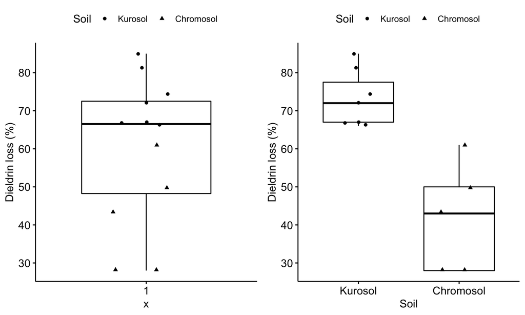

**Total dieldrin loss since 1988 (%) per soil and paddock:**  
Total dieldrin loss was recorded per paddock only (n = 12)

| Soil | Dieldrinloss | n | mean | sd |
| --- | --- | --- | --- | --- |
| Kurosol | Dloss | 21 | 73.143 | 7.045 |
| Chromosol | Dloss | 15 | 42.000 | 13.240 |

| Paddock | Dieldrinloss | n | mean | se |
| --- | --- | --- | --- | --- |
| 1 | Dloss | 3 | 81 | 0 |
| 2 | Dloss | 3 | 72 | 0 |
| 3 | Dloss | 3 | 74 | 0 |
| 4 | Dloss | 3 | 67 | 0 |
| 5 | Dloss | 3 | 66 | 0 |
| 6 | Dloss | 3 | 67 | 0 |
| 7 | Dloss | 3 | 85 | 0 |
| 8 | Dloss | 3 | 28 | 0 |
| 9 | Dloss | 3 | 61 | 0 |
| 10 | Dloss | 3 | 28 | 0 |
| 11 | Dloss | 3 | 50 | 0 |
| 12 | Dloss | 3 | 43 | 0 |

# Power analysis

**Questions:**

1. From the available 36 samples (21 for soil 1 and 15 for soil 2), **how much power does a suitable test have** to determine if there are significant differences between the two soils? If I understand power correctly, then it is the chance of getting a significant results i.e. power = percent(<=0.05).
2. **How many samples are needed** per sample to get the true mean of dieldrin concentrations?
3. **How many paddocks are needed** to model biological data to dieldrin loss?

**Some reading**  
- Statistical power analysis: A simple and general model for traditional and modern hypothesis tests (Murphy, Myors, and Wolach 2014)  
- Statistical Power Analysis (Cohen 1992)  
- Bootstrap Methods and their Application (Davison and Hinkley 1997)

**Videos**  
- [Bootstrap Confidence Interval with R | R Video Tutorial 4.5](https://www.youtube.com/watch?v=Om5TMGj9td4)

## Question 1

**How much power does the result have?** The following is based on the pwr package vignette:  
https://cran.r-project.org/web/packages/pwr/vignettes/pwr-vignette.html

### t-test

An option to answer question 1: How powerful is this experiment if we want to detect a “large” effect in either direction with a significance level of 0.05

```r
# Effect size large = 0.8

pwr.t.test(n = 15, d = 0.8, sig.level = 0.05)
```

```
##
##      Two-sample t test power calculation
##
##               n = 15
##               d = 0.8
##       sig.level = 0.05
##           power = 0.5617849
##     alternative = two.sided
##
## NOTE: n is number in *each* group
```

```r
pwr.t.test( d = 0.8, sig.level = 0.05, power = 0.8)
```

```
##
##      Two-sample t test power calculation
##
##               n = 25.52458
##               d = 0.8
##       sig.level = 0.05
##           power = 0.8
##     alternative = two.sided
##
## NOTE: n is number in *each* group
```

Result:  
The sample size is uneven between the two soils (n= 21, n = 15) so the t-test is not suitable. However, doing it anyway and using the lower number of n (n = 15) and a large effect size (how do we actually calculate d for t-tests as 0 -1?), the power of a t-test would be relatively low (power = 0.56).

If we wanted to redo this experiment (using equal sample sizes) 25 samples per soil are needed to test for significant differences at a power of 0.8.